# R Notebook

**Disclaimer: All data is randomly generated and is not “real” (collected from real-life participants)**

### **Loading packages:**

```r
library(tidyverse)
```

```r
library(ggplot2)
library(gridExtra)
library(RColorBrewer)
```

### **Reading data in:**

```r
(df1 = read_csv("Repo.long.csv"))
```

| ID | Ability | Confidence | Treatment_time | Final_Grade | ab_diff | con_diff |
| --- | --- | --- | --- | --- | --- | --- |
| 1 | 6 | 5 | Pre | C | 3 | 0 |
| 2 | 10 | 2 | Pre | A | 2 | 2 |
| 3 | 10 | 5 | Pre | B | 1 | -3 |
| 4 | 12 | 3 | Pre | B | 0 | -2 |
| 5 | 6 | 4 | Pre | B | 4 | 1 |
| 6 | 8 | 5 | Pre | A | 2 | -1 |
| 7 | 9 | 4 | Pre | B | 3 | -1 |
| 8 | 8 | 5 | Pre | C | 1 | -1 |
| 9 | 5 | 3 | Pre | D | 3 | -1 |
| 10 | 4 | 1 | Pre | F | -2 | 4 |

[output cut: 50 more lines]

```r
(df2 = read_csv("Repo.wide.csv"))
```

| ID | Pre_ability | Post_ability | Pre_confidence | Post_confidence | Final_Grade | X7 |
| --- | --- | --- | --- | --- | --- | --- |
| 1 | 6 | 9 | 5 | 5 | C | NA |
| 2 | 10 | 12 | 2 | 4 | A | NA |
| 3 | 10 | 11 | 5 | 2 | B | NA |
| 4 | 12 | 12 | 3 | 1 | B | NA |
| 5 | 6 | 10 | 4 | 5 | B | NA |
| 6 | 8 | 10 | 5 | 4 | A | NA |
| 7 | 9 | 12 | 4 | 3 | B | NA |
| 8 | 8 | 9 | 5 | 4 | C | NA |
| 9 | 5 | 8 | 3 | 2 | D | NA |
| 10 | 4 | 2 | 1 | 5 | F | NA |

[output cut: 20 more lines]

### **Data manipulation:**

Noticed an extra empty column that got read in from repo.wide.csv file so removing that

```r
df2 = df2 %>% select(-X7)
```

Creating new variables to represent change between 2 treatments

```r
df2 = df2 %>% mutate(ab_diff = Post_ability - Pre_ability) #generating difference in ability between pre and post treatment
df2 = df2 %>% mutate(con_diff = Post_confidence - Pre_confidence) #generating difference in confidence between pre and post treatment
```

Creating a new variable that shows whether ability between treatments is better, worse or the same

```r
df1$ab_position = ifelse(df1$ab_diff < 0, "Decreased", ifelse(df1$ab_diff >0, "Increased", "Stayed same"))
df1$ab_position_r = factor(df1$ab_position, levels=c('Increased','Stayed same','Decreased'))
```

Creating factors for the final grades (more useful if had sub grades e.g. A+, A- etc.)

```r
df1$Final_Grade_r = factor(df1$Final_Grade, levels = c("A", "B", "C", "D", "F"))
```

### **Plotting data:**

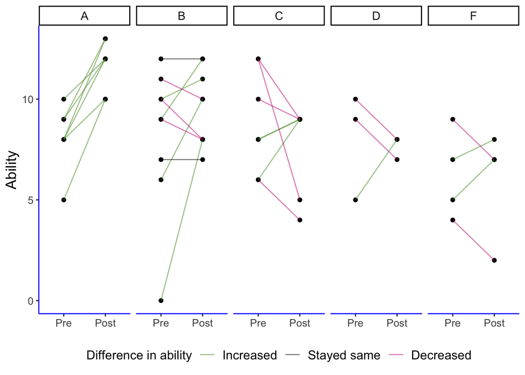

```r
g1 = ggplot(df1, aes(x = fct_inorder(Treatment_time), y = Ability, group = ID)) +
  geom_point() +
  geom_line(alpha=0.5, aes(colour=ab_position_r)) +
  scale_colour_manual(values = c("#4d9221", "#000000", "#c51b7d")) +
  facet_wrap(~df1$Final_Grade_r, ncol = 5, nrow = 1) +
  labs(x=NULL, y = "Ability", colour = "Difference in ability") +
  theme_classic() +
  theme(text = element_text(size=14),
        axis.title.y = element_text(size = 14),
        axis.text.x = element_text(size = 10),
        axis.text.y = element_text(size = 10),
        axis.line = element_line(colour = "blue"),
        legend.position = "bottom",
        legend.text = element_text(size = 12),
        legend.title = element_text(size = 12))
g1
```

g1 shows each individual’s progress between the two treatments in a course, split up by groups based on grades received from an end of year test. We see that A grade students show the most increase in ability from the treatment and C grade students show the opposite. They’re interesting groups to compare because their scores before the treatment were quite similar (Pre), however after the treatment (Post) they deviate. This suggests that the same treatment can have different effects based on the grade an individual gets (or is set to get) and that there is something else going on.

```r
library(MASS)
```

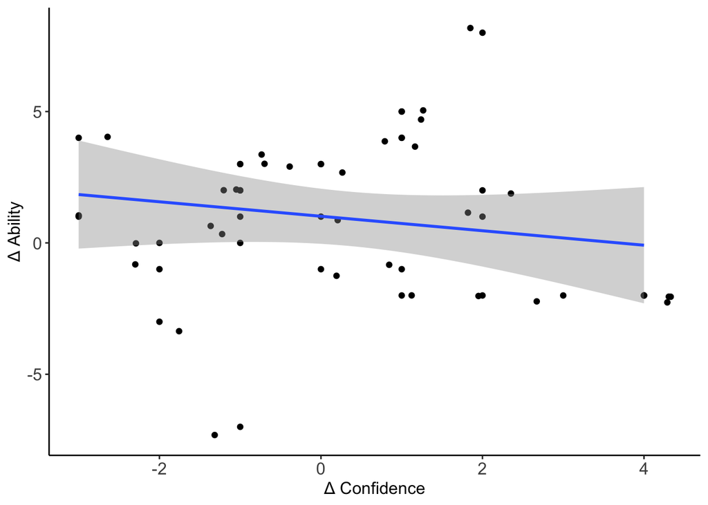

```r
g2 = ggplot(df2, aes(x = con_diff, y = ab_diff)) +
  geom_point() +
  geom_jitter() +
  geom_smooth(method = "rlm") +
  theme_classic() +
  theme(text = element_text(size=12),
        axis.title.y = element_text(size = 12),
        axis.text.x = element_text(size = 12),
        axis.text.y = element_text(size = 12)
        ) +
  labs(x="Δ Confidence", y = "Δ Ability")
g2
```

```r
detach(package:MASS) #interferes with select fn
```

Small decreasing trend between change in confidence and change in ability. Negative numbers for both change in confidence and ability indicate loss post treatment and vice versa. A decreasing trend suggests that as ability is lost, confidence grows hinting as a possible observation of the Duning-Kruger effect. Need further statistical analyses to untangle this further.